# Exploratory Data Analysis Project- Gapminder Dataset

## 3.1.2. Raw Data Visualization

# a) Boxplots

Life expectancy comparision in different region

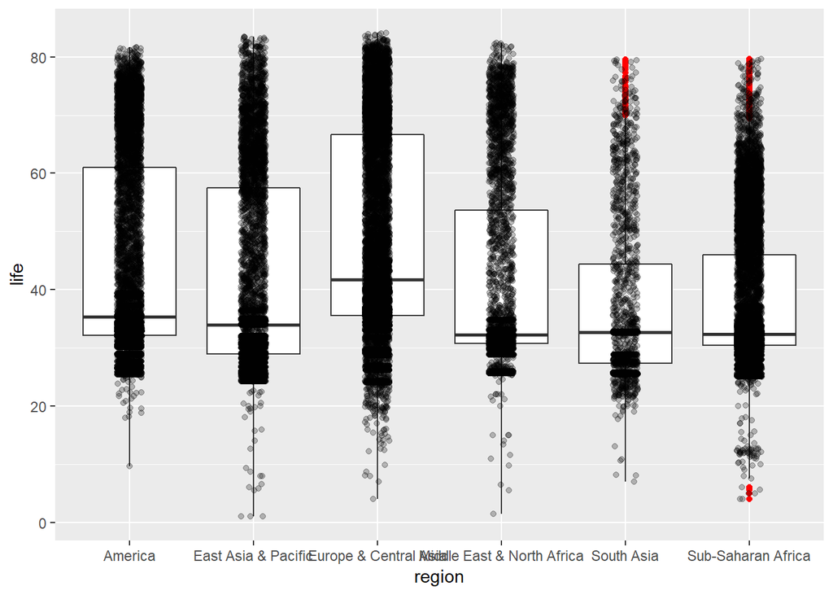

```r
library(ggplot2)
ggplot(gapminder, aes(x = region, y = life)) +  geom_boxplot(outlier.colour = "red") +  geom_jitter(position = position_jitter(width = 0.1, height = 0), alpha = 1/4)
```

Population comparision in different region

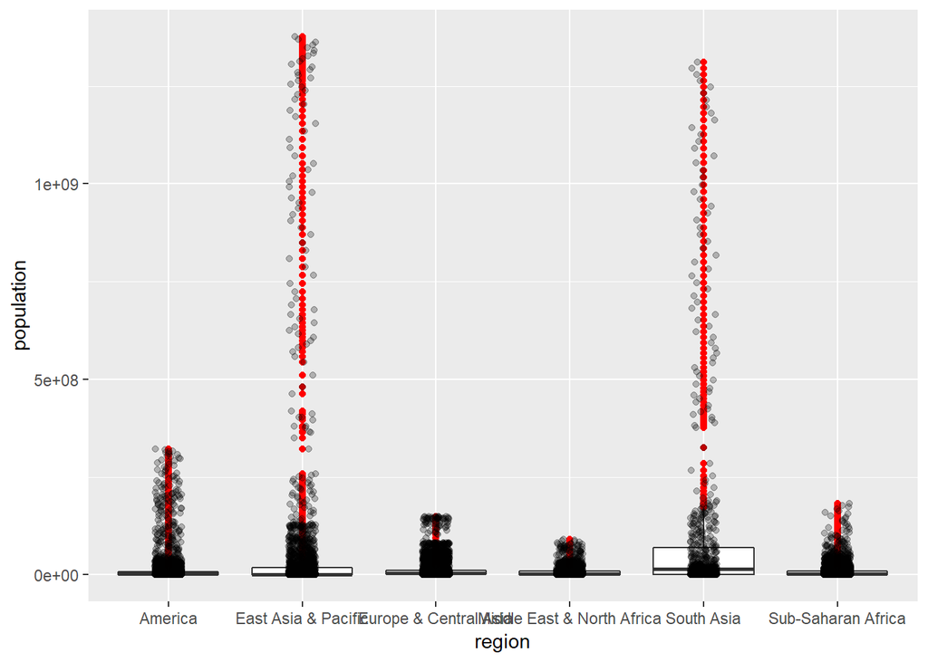

```r
ggplot(gapminder, aes(x = region, y = population)) +  geom_boxplot(outlier.colour = "red") +  geom_jitter(position = position_jitter(width = 0.1, height = 0), alpha = 1/4)
```

Income comparision in different region

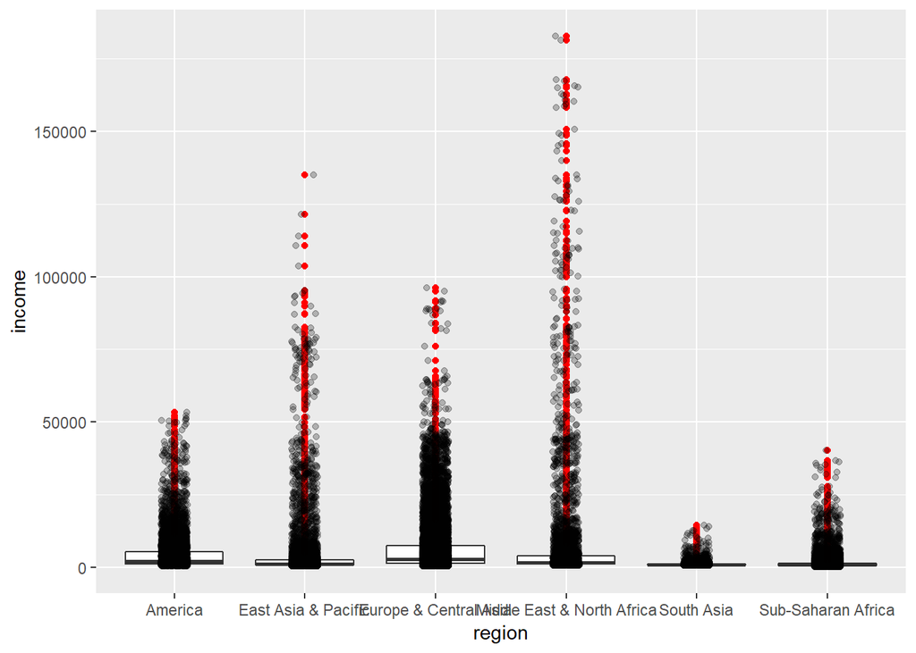

```r
ggplot(gapminder, aes(x = region, y = income)) +  geom_boxplot(outlier.colour = "red") +  geom_jitter(position = position_jitter(width = 0.1, height = 0), alpha = 1/4)
```

# b) Histograms

Life Expectancy by region

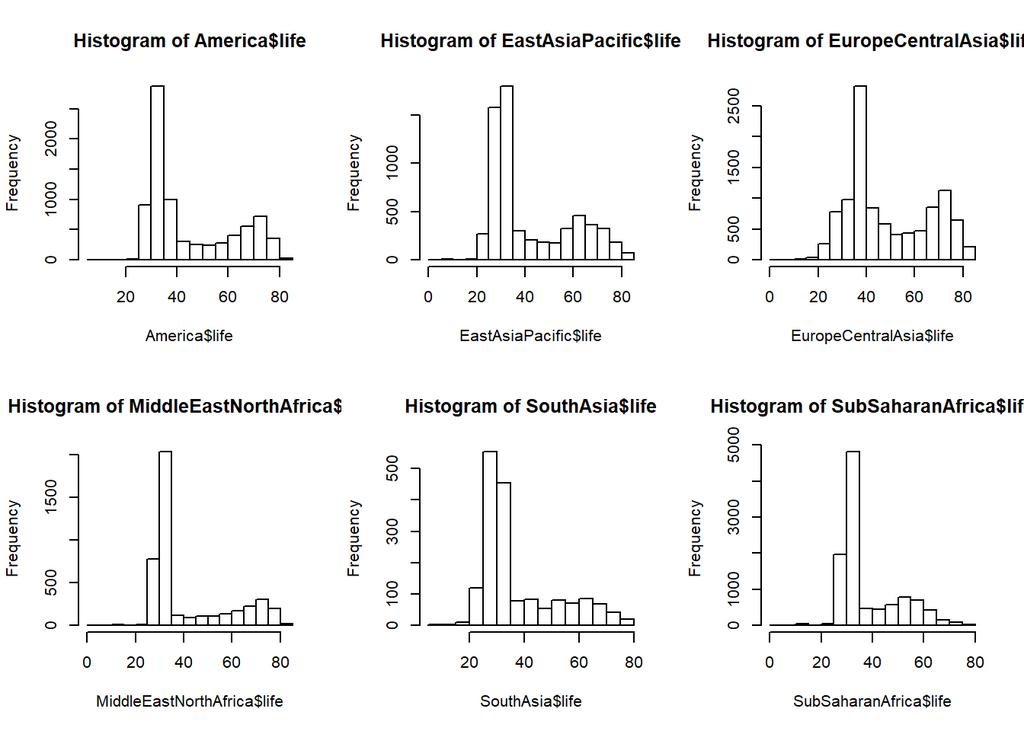

```r
library(ggplot2)
par(mfrow=c(2,3))
hist(America$life)
hist(EastAsiaPacific$life)
hist(EuropeCentralAsia$life)
hist(MiddleEastNorthAfrica$life)
hist(SouthAsia$life)
hist(SubSaharanAfrica$life)
```

# c) Density plots

Density Plot of life expectancy by region

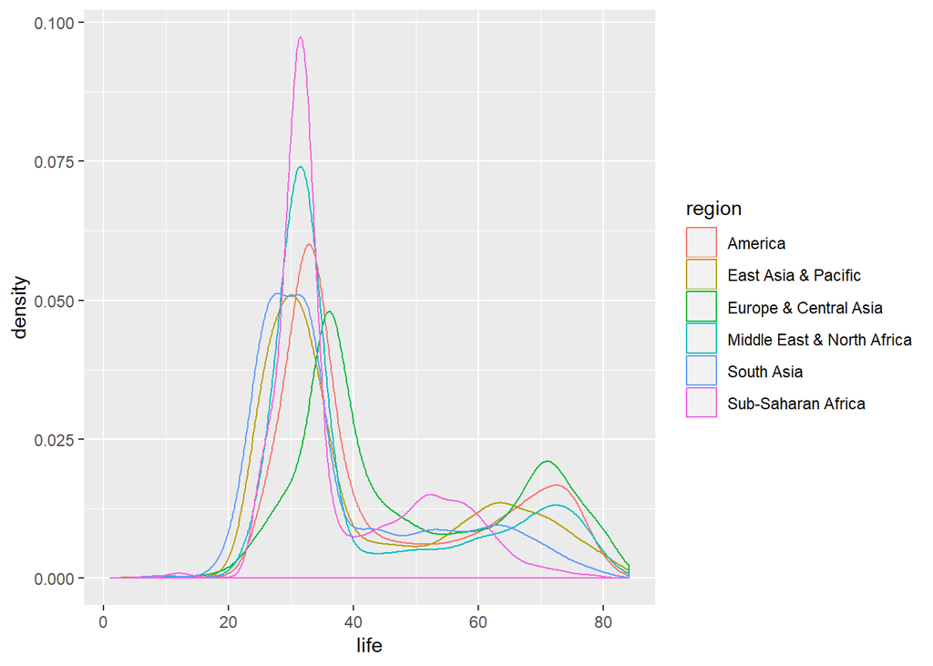

```r
ggplot(gapminder,aes(life))+geom_density(aes(color=region))
```

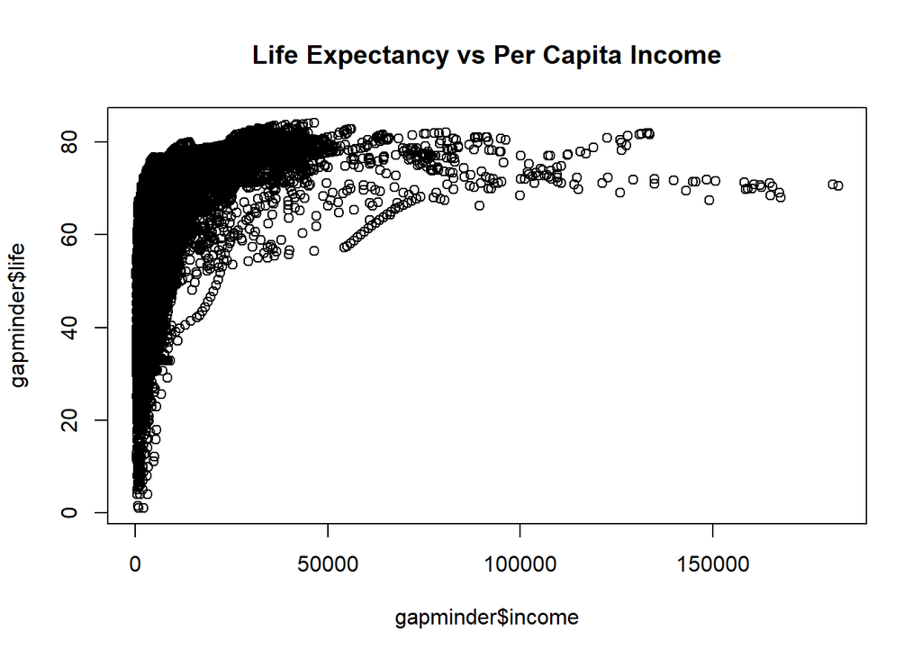

```r
plot(gapminder$income, gapminder$life, main = "Life Expectancy vs Per Capita Income" )
```

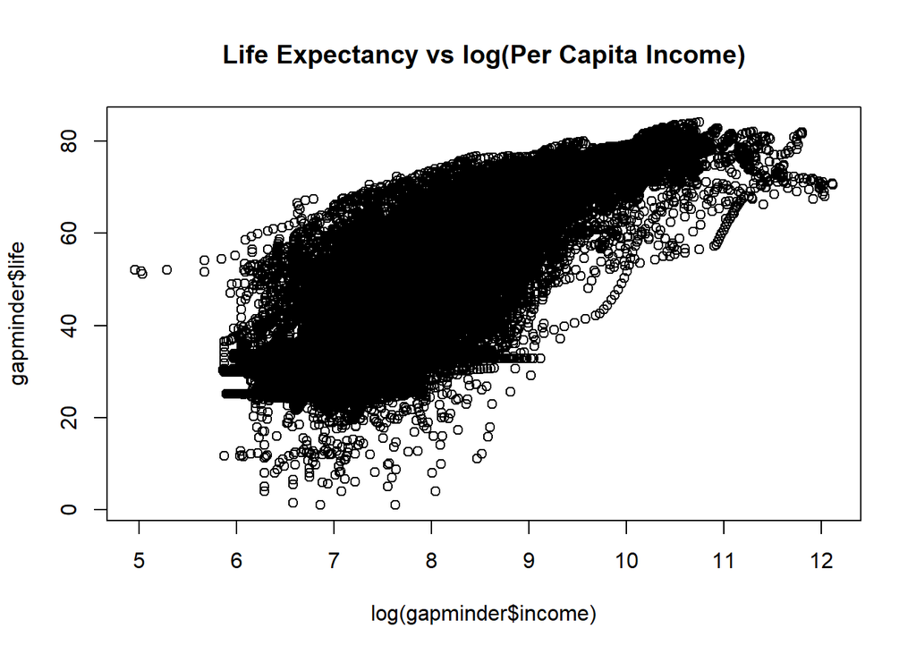

```r
plot(log(gapminder$income), gapminder$life, main = "Life Expectancy vs log(Per Capita Income)")
```

## 3.1.4 Life expectancy trends over the years for different regions/subcontinents

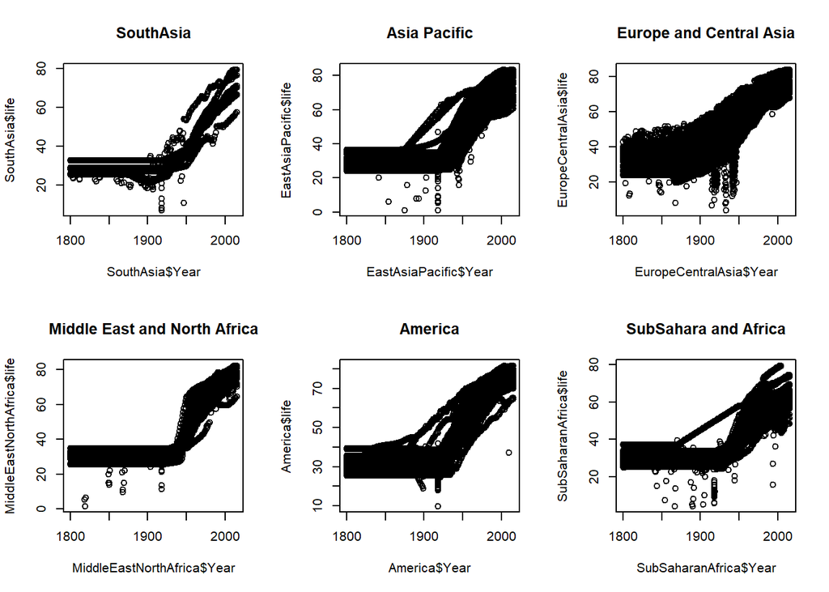

```r
par(mfrow=c(2,3))
plot(SouthAsia$Year, SouthAsia$life, main = "SouthAsia")
plot(EastAsiaPacific$Year, EastAsiaPacific$life, main = "Asia Pacific")
plot(EuropeCentralAsia$Year, EuropeCentralAsia$life, main = "Europe and Central Asia")
plot(MiddleEastNorthAfrica$Year, MiddleEastNorthAfrica$life, main = "Middle East and North Africa")
plot(America$Year, America$life, main = "America")
plot(SubSaharanAfrica$Year, SubSaharanAfrica$life, main = "SubSahara and Africa")
```

# 3.2 Exploratory data analysis for a single country (United States)

```r
gapminderUS=filter(gapminder,Country=="United States")
```

# Data summary and statistics

Five-number summaries for different variables for the US

```r
fivenum(gapminderUS$life)
```

```
## [1] 31.000 39.410 50.550 69.938 79.100
```

```r
fivenum(gapminderUS$population)
```

```
## [1]   6801854 170796378 218963561 266275528 321773631
```

```r
fivenum(gapminderUS$income)
```

```
## [1]  2115.0  3505.0  7875.0 19231.5 53354.0
```

# a) Boxplots for different variables for the US

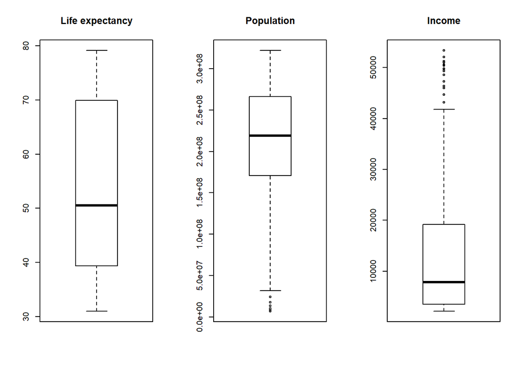

```r
par(mfrow=c(1,3))
boxplot(gapminderUS$life, main = "Life expectancy")
boxplot(gapminderUS$population, main = "Population")
boxplot(gapminderUS$income, main = "Income")
```

# b) Histograms for different variable for the US

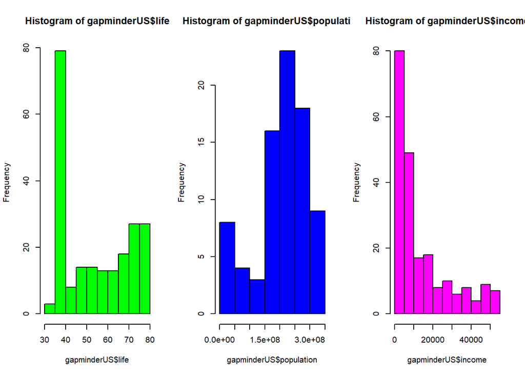

```r
par(mfrow=c(1,3))
hist(gapminderUS$life,col = "green")
hist(gapminderUS$population,col = "blue")
hist(gapminderUS$income,col="magenta")
```

# c) Density Plots for different variables for the US

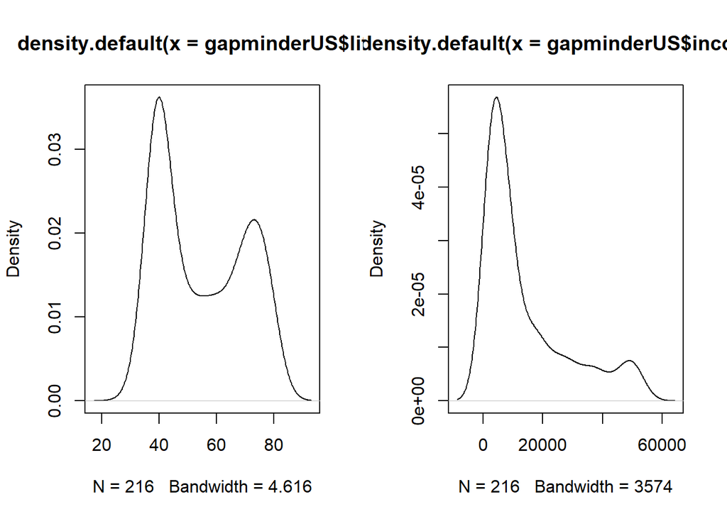

```r
par(mfrow=c(1,2))
plot(density(gapminderUS$life))
plot(density(gapminderUS$income))
```

## 3.2.3. Analysis of ‘Life Expectancy’ vs ‘Per Capita Income’ for the United States

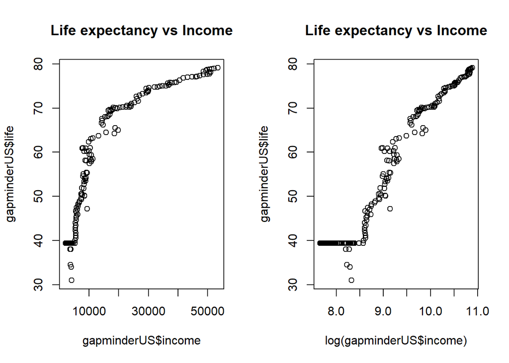

```r
par(mfrow=c(1,2))
plot(gapminderUS$income, gapminderUS$life, main = "Life expectancy vs Income")
plot(log(gapminderUS$income), gapminderUS$life, main = "Life expectancy vs Income")
```

## 3.2.3. Analysis of ‘Life Expectancy’, ‘Population’ and ‘Per Capita Income’ variation over the years for the United States

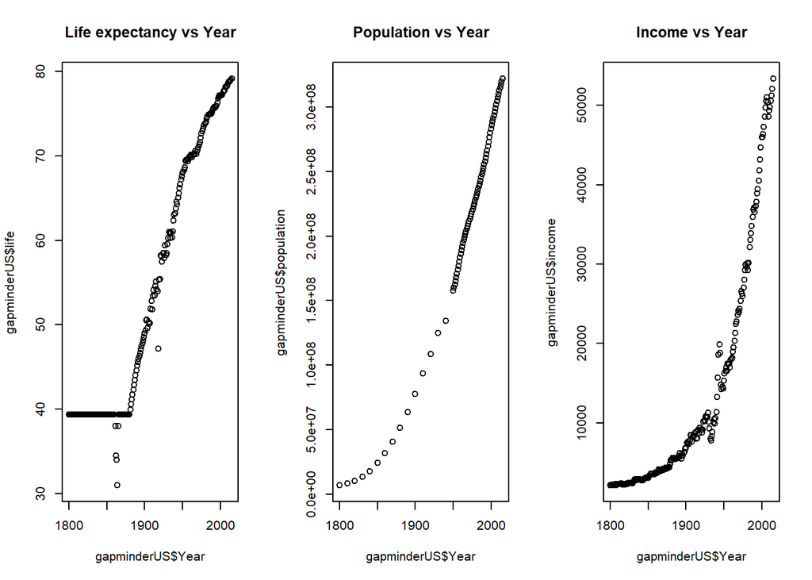

```r
par(mfrow=c(1,3))
plot(gapminderUS$Year, gapminderUS$life, main = "Life expectancy vs Year")
plot(gapminderUS$Year, gapminderUS$population, main = "Population vs Year")
plot(gapminderUS$Year, gapminderUS$income, main = "Income vs Year")
```